# Recreational Survey – Shakedown August 2022

August 15 - 16, 2022 [*F/V Fin Chaser*](https://finchasersportfishing.com/) Ocean City, MD

Author

Mike O’Brien (UMCES)

## Participants

### August 15

- Dave Secor: 301-481-5053
- Mike O’Brien: 267-970-1973

### August 16

- Dave Secor
- Mike O’Brien
- Todd Sumner: 443-240-2824
- Capt. Dan Stauffer
- *Fin Chaser* mate

## Schedule

### 15 August

- Scientific crew (DHS, MOB)
  - pack CBL truck (2013 Silverado) at Solomons, MD. Drive to West Ocean City, MD
  - purchase dry ice at Safeway in Chester, MD
    - 1925 Main St, Chester, MD 21619
  - Check into [Beach Bum West-O](https://beachbumwesto.com/)
    - 12308 Old Bridge Road, Ocean City, Maryland 21842
    - Conf. #: LAMACMD03207533

## Cruise plan

Times calculated at 12 knots.

- 0500: MOB, DHS, TS meet at Talbot St Pier, load gear onto *F/V Fin Chaser*
- 0530: *Fin Chaser* depart Talbot St Pier, transit to **Great Eastern Reef** control site
  - **38 25.829, 74 46.062**
- 0655: Arrive Great Eastern Reef control site.
  - Mate arranges gear for jigging.
  - Sci crew organizes MS-222 bucket
  - Environmental data recorded
- 0705: Mate begins jigging for 15 minutes.
  - All fish are weighed and measured.
  - First 10 black sea bass are sacrificed.
- 0720 Mate ends jigging.
- 0725: Survey crew begins drop survey.
  - 15 x 3 minute drops.
  - All fish are weighed and measured.
  - First 10 black sea bass are sacrificed.
- 0900: Drop survey ends. Transit to **K07** experimental site.
  - **38 21.201, 74 42.15**
- 0930: Arrive K07 experimental site.
- 0940: Mate begins jigging for 15 minutes. Data and specimen collection as above.
- 0955: Mate ends jigging.
- 1000: Survey crew begins drop survey, conducted as above.
- 1130: Drop survey ends. Return to Talbot St Pier.
- 1305: Arrive Talbot St Pier. Unload gear.

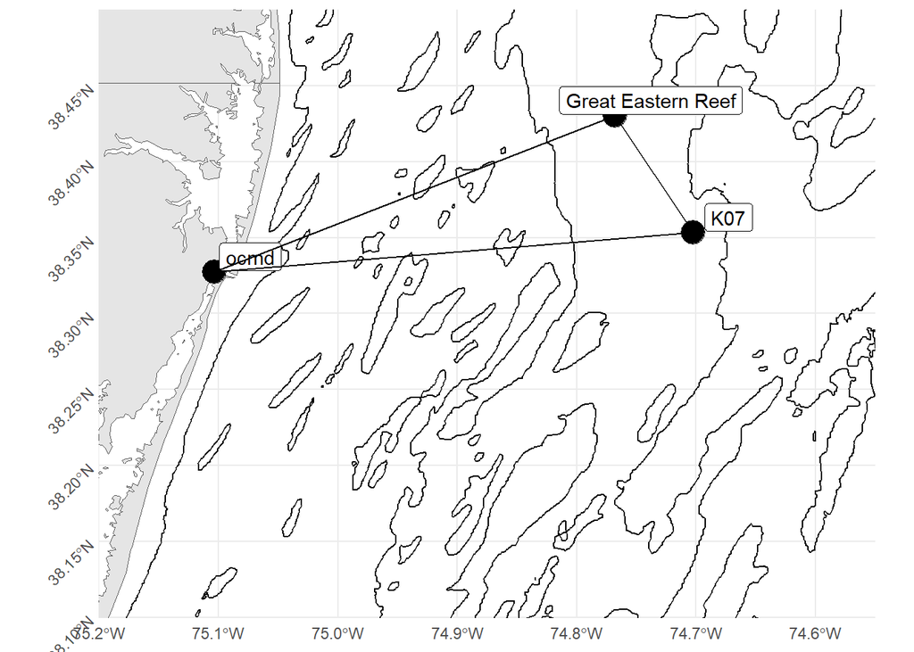

Distance, nautical miles

|  | ocmd | Great Eastern Reef | K07 |
| --- | --- | --- | --- |
| ocmd | 0.00 | 16.97 | 18.94 |
| Great Eastern Reef | 16.97 | 0.00 | 5.56 |
| K07 | 18.94 | 5.56 | 0.00 |

Distance, time

|  | ocmd | Great Eastern Reef | K07 |
| --- | --- | --- | --- |
| ocmd | 00 h 00 m | 01 h 25 m | 01 h 35 m |
| Great Eastern Reef | 01 h 25 m | 00 h 00 m | 00 h 30 m |
| K07 | 01 h 35 m | 00 h 30 m | 00 h 00 m |